# Wrangle_Report

### INTRODUCTION

This project seeks to gather and analyze data from the WeRateDogs twitter page.

### GATHERING

The data required for this project was in three different files which needed to be retrieved and loaded onto the jupyter notebook for assessment. The files are:

- **The CSV file**

This is the `twitter-archive-enhanced.csv` file. The file was uploaded into a dataframe using the pandas `pd.read_csv` function

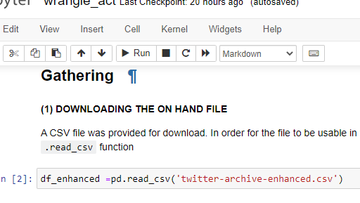

- **The TSV file**

This is the `image-predictions.tsv` file. The request function `request.get()` was used to retreive this information form the url of the site. The downloaded file was then written into the system memory using the `with open` function. The file was then uploaded into a dataframe by using the pandas `pd.read_csv` function with the required specifications.

[figure not shown]

- **The Twitter json file**

The empty dictionary `tweet_json` was created for later use in the creation of the required dataframe. Following this the `with open` function was used to read in the json txt file which had been downloaded from the udacity website. 3 custom functions were created to extract the required data from the txt file. The functions are shown in the image below:

[figure not shown]

### ASSESSING

Three datarames: `df_enhanced`,`df_predict`,`df_json`, have been created. The dataframes were assessed visually and programmatically using the `.info()`, `.sample()`,`.head()` functions. The `df_enhanced` data was further assessed using microsoft excel.

The issues noted were categorised after each dataset as shown in the image below:

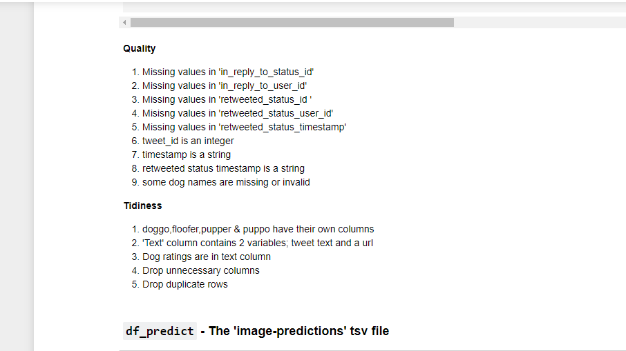

### CLEANING

Before cleaning begins, copies of that dataframes are loaded into new dataframes to be cleaned.

- **Completeness**

The data is incomplete but the data required to fill the dataframe cannot be retrieved so the cells remain null.

- **Tidiness** There are 5 core tidiness issues
1. doggo,floofer,pupper & puppo have their own columns
2. 'Text' column contains 2 variables; tweet text and a url
3. Dog ratings are in text column
4. Unnecessary columns
5. Duplicate rows

**a)**

All three dataframes will be condensed into a single dataframe using the `pd.merge()` function before further cleaning takes place

[figure not shown]

**b)**

- The image url is contained in the `'text'` column along with the rest of the tweet text. It is extracted using the regular expression function `.extract()` into a new column named 'image_url'.
- The 'jpg_url' column is dropped to avoid duplicity

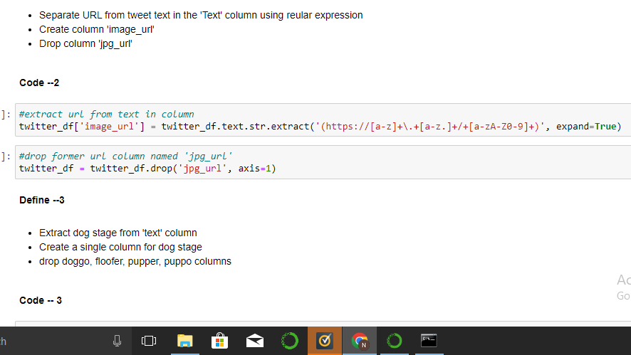

**c)**

- The dog category is extracted from the `'text` column into a new column called `'dog category` using the regular expression `.extract()` function
- The doggo,floofer,pupper & puppo columns are dropped

**d)**

The numerator of the dog rating was extracted into a new column using the regex function `.extract()`

**e)**

Columns that were not necessary for visualization were dropped using the `.drop()` function in pandas

## Quality

- 'tweet_id' is integer data
- 'timestamp' is string data
- 'dog_category' is string data
- 'rating_num' is string data
- Conversion of the data to their appropriate data types of the 'tweet_id', 'dogz-category' and 'rating_num' columns are resolved by using the pandas `.astype()` function.
- The 'timestamp' coumn is converted to datetime data is done via the use of the pandas `.to_datetime()` function

## Storage

The cleaned data is stored as a csv file using the pandas `.to_csv()` function